# Análisis exploratorio

María Sánchez Vivo

2026-05-05

# **Introducción**

En este script se realiza un análisis exploratorio básico para ver los datos de los que se dispone (ver cuántas muestras hay de cada enfermedad, cuántos H/M hay, si las muestras están también en el archivo de datos metataxonómicos) y comprobar que está todo limpio, es decir, que no hay ninguna fila ni columna repetidas ni valores nulos, NA.

# **Análisis básico**

Se empieza por la carga de datos: datos clínicos, metabolómicos, metataxonómicos y datos de abundancia 16S.

```r
datos_metabolitos <- readRDS("metabolitos.rds")
datos_metataxonomicos <- readRDS("tax.rds")
datos_clinicos <- readRDS("covs.rds")
datos_abundancia_16S <- readRDS("metagen.rds")
```

Contamos con 46 muestras y 1444 datos metataxonómicos encontrados en las mismas, gracias a secuenciación 16S.

Antes de comenzar el análisis, se realiza una primera exploración para comprobar la calidad de los datos. En concreto, se evalúa la presencia de columnas o filas duplicadas, así como la existencia de valores perdidos (NA) en los distintos datasets.

```r
#Ver si hay columnas repetidas en datasets
sapply(list(datos_abundancia_16S, datos_clinicos, datos_metabolitos, datos_metataxonomicos), \(x) any(duplicated(names(x))))
```

```
## [1] FALSE FALSE FALSE FALSE
```

```r
#Ver si hay filas repetidas en datasets
sapply(list(datos_abundancia_16S, datos_clinicos, datos_metabolitos, datos_metataxonomicos), \(x) any(duplicated(x)))
```

```
## [1] FALSE FALSE FALSE FALSE
```

```r
#Ver si hay NAs en datasets
sapply(list(datos_abundancia_16S, datos_clinicos, datos_metabolitos, datos_metataxonomicos), \(x) any(is.na(x)))
```

```
## [1] FALSE FALSE FALSE FALSE
```

No hay ninguna variable (columnas) ni datos (filas) repetidos en ningún archivo, tampoco hay presente ningún NA.

Se verifica que las muestras estén correctamente alineadas entre los distintos datasets (clínicos, 16S y metabolitos), comprobando que no falte ninguna ni existan discrepancias entre ellos.

```r
#Ver que las muestras son las mismas en todos los datasets
muestras_dc <- unique(datos_clinicos$Sample)
muestras_da16S <- unique(datos_abundancia_16S$Sample)
muestras_dm <- unique(datos_metabolitos$Sample)

c(
  comunes = length(Reduce(intersect, list(muestras_dc, muestras_da16S, muestras_dm))),
  solo_clinicos = length(setdiff(muestras_dc, union(muestras_da16S, muestras_dm))),
  solo_16S = length(setdiff(muestras_da16S, union(muestras_dc, muestras_dm))),
  solo_metabolitos = length(setdiff(muestras_dm, union(muestras_dc, muestras_da16S)))
)
```

```
##          comunes    solo_clinicos         solo_16S solo_metabolitos
##               46                0                0                0
```

Con todos los resultados anteriores, se determina que los datasets están limpios.

A través de la herramienta *summary* se realiza un análisis básico de los datasets. Empezando por los datos clínicos:

```r
library(dplyr)

datos_clinicos_limpios <- datos_clinicos %>%
  select(-ends_with("_0"))                    #Hay algunas variables repetidas "_0" / "_1

#Me quedo con las muestras "_1"; más fácil de interpretar. Se reduce el nº de columnas.

vars_id <- c("Sample")

vars_num_clin <- datos_clinicos_limpios %>%
  dplyr::select(-all_of(vars_id)) %>%
  dplyr::select(where(is.numeric)) %>%
  dplyr::select(where(~ n_distinct(., na.rm = TRUE) >= 0)) %>%
  names()

vars_cat_clin <- datos_clinicos_limpios %>%
  dplyr::select(-all_of(vars_id)) %>%
  dplyr::select(where(~ is.factor(.) | is.character(.))) %>%
  dplyr::select(where(~ n_distinct(., na.rm = TRUE) >= 0)) %>%
  names()

cat("Variables clínicas numéricas:", length(vars_num_clin), "\n")
```

```
## Variables clínicas numéricas: 35
```

```r
cat("Variables clínicas categóricas:", length(vars_cat_clin), "\n")
```

```
## Variables clínicas categóricas: 96
```

```r
cat("Total de variables clínicas:", length(vars_num_clin) + length(vars_cat_clin), "\n")
```

```
## Total de variables clínicas: 131
```

```r
summary(datos_clinicos_limpios)
```

```
##     Sample              idade        tempo_mostra     a1_final_mm2
##  Length:46          Min.   :18.94   Min.   : 357.0   Min.   : 0.400
##  Class :character   1st Qu.:47.07   1st Qu.: 697.2   1st Qu.: 3.625
##  Mode  :character   Median :54.29   Median :1377.0   Median : 8.000
##                     Mean   :52.20   Mean   :1813.5   Mean   : 8.670
##                     3rd Qu.:60.11   3rd Qu.:2694.2   3rd Qu.:11.625
##                     Max.   :77.05   Max.   :7404.0   Max.   :28.000
##  a2_inicial_mm2   media_a1_a2     genero diagnostico_principal  n_fragmentos
##  Min.   : 2.70   Min.   : 2.700   M:24   Healthy:12            Min.   :1.000
##  1st Qu.: 6.15   1st Qu.: 5.701   F:22   VHC    :14            1st Qu.:1.000
##  Median : 9.60   Median : 8.625          HAI    : 8            Median :1.000
##  Mean   :10.69   Mean   : 9.662          CBP    :12            Mean   :1.587
##  3rd Qu.:12.39   3rd Qu.:12.319                                3rd Qu.:2.000
##  Max.   :30.80   Max.   :29.000                                Max.   :6.000
##  comprimento_da_biopsia_mm n_espacos_porta_ep n_espacos_porta_completos_ep
##  Min.   : 2.00             Min.   : 2.00      Min.   : 0.00
##  1st Qu.:11.00             1st Qu.:10.50      1st Qu.: 3.25
##  Median :13.00             Median :15.00      Median : 6.00
##  Mean   :13.93             Mean   :14.98      Mean   : 7.50
##  3rd Qu.:14.75             3rd Qu.:19.00      3rd Qu.:11.00
##  Max.   :60.00             Max.   :36.00      Max.   :26.00
##  n_ep_sem_ducto   n_ep_sem_arteriola n_ep_sem_arteriola_e_sem_ducto
##  Min.   :0.0000   Min.   :0          Min.   :0.00000
##  1st Qu.:0.0000   1st Qu.:0          1st Qu.:0.00000
##  Median :0.0000   Median :0          Median :0.00000
##  Mean   :0.1957   Mean   :0          Mean   :0.04348
##  3rd Qu.:0.0000   3rd Qu.:0          3rd Qu.:0.00000
##  Max.   :2.0000   Max.   :0          Max.   :1.00000
##  n_ep_inflamados    siderosis      siderosis_topografia granulomas_epitelioides
##  Min.   : 0.000   Min.   :0.0000   Min.   :0.0000       Min.   :0.0000
##  1st Qu.: 2.000   1st Qu.:0.0000   1st Qu.:0.0000       1st Qu.:0.0000
##  Median : 5.000   Median :0.0000   Median :0.0000       Median :0.0000
##  Mean   : 7.283   Mean   :0.2826   Mean   :0.2609       Mean   :0.2174
##  3rd Qu.:10.750   3rd Qu.:0.0000   3rd Qu.:0.0000       3rd Qu.:0.0000
##  Max.   :30.000   Max.   :3.0000   Max.   :3.0000       Max.   :2.0000
##  predominio_de_tipo_de_celulas_inflamatorias_49      inr
##  Min.   :0.000                                  Min.   :0.8500
##  1st Qu.:0.000                                  1st Qu.:0.9825
##  Median :2.000                                  Median :1.0300
##  Mean   :2.217                                  Mean   :1.0513
```

[output cut: 337 more lines]

```
##
##  quelantes_antes_de_biopsia diabetes_1 diabetes_tratada_1 hta_1  hta_tratada_1
##  1:46                       0:45       0:45               0:39   0:39
##                             1: 1       1: 1               1: 7   1: 7
##
##
##
##
##  dislipidemia_1 dislipidemia_tratada_1 transplante_hepatico_n_1
##  0:39           0:39                   0:43
##  1: 7           1: 7                   1: 3
##
##
##
##
```

A partir de este resumen de datos clínicos:

- Diagnóstico (enfermedades): hay 12 controles, 14 muestras de VHC (Virus de la Hepatitis C), 8 muestras de HAI (Hepatitis autoinmune) y 12 muestras de CBP (Colangitis biliar primaria).
- Sexo: las muestras son de 22 mujeres (47,83%) y 24 hombres (52,17%).
- Se aprecian muchas variables de topografía, localización, células del sistema inmunitario (y otras variables de predominio de las mismas), morfología, fibrosis, fármacos y enfermedades. (0=NO, 1=SÍ).

Una vez analizado de forma básica el dataset de los datos clínicos, se exploran las características generales del dataset de metabolitos:

```r
summary(datos_metabolitos)
```

```
##     Sample            imidazole         alanine        betaine_aldehyde
##  Length:46          Min.   :0.1142   Min.   :0.07911   Min.   :0.0000
##  Class :character   1st Qu.:0.9994   1st Qu.:0.11812   1st Qu.:0.0000
##  Mode  :character   Median :2.0327   Median :0.13906   Median :0.0000
##                     Mean   :2.3670   Mean   :0.15677   Mean   :0.2553
##                     3rd Qu.:2.8467   3rd Qu.:0.18949   3rd Qu.:0.3335
##                     Max.   :9.6606   Max.   :0.31726   Max.   :2.1563
##     choline       dimethylglycine       serine         creatinine
##  Min.   :0.1079   Min.   :0.09932   Min.   :0.2157   Min.   : 0.1094
##  1st Qu.:0.2340   1st Qu.:0.21865   1st Qu.:0.3322   1st Qu.: 0.1797
##  Median :0.3521   Median :0.31164   Median :0.4681   Median : 0.6148
##  Mean   :0.5185   Mean   :0.50554   Mean   :0.4891   Mean   : 1.4275
##  3rd Qu.:0.8048   3rd Qu.:0.80430   3rd Qu.:0.5983   3rd Qu.: 1.1908
##  Max.   :1.5212   Max.   :1.65814   Max.   :0.9772   Max.   :18.0447
##     proline            valine         threonine       nicotinamide
##  Min.   :0.09214   Min.   :0.1021   Min.   :0.1618   Min.   : 0.05387
##  1st Qu.:0.15013   1st Qu.:0.1911   1st Qu.:0.2529   1st Qu.: 0.84610
##  Median :0.19241   Median :0.2570   Median :0.3211   Median : 1.53410
##  Mean   :0.19992   Mean   :0.2481   Mean   :0.4032   Mean   : 2.49243
##  3rd Qu.:0.23886   3rd Qu.:0.2941   3rd Qu.:0.4238   3rd Qu.: 2.87320
##  Max.   :0.37916   Max.   :0.5352   Max.   :1.3597   Max.   :11.86086
##  leucine_isoleucine methylcysteine      glutamine          guanine
##  Min.   :0.04013    Min.   :0.09438   Min.   :0.04918   Min.   : 0.2219
##  1st Qu.:0.07763    1st Qu.:0.14129   1st Qu.:0.09440   1st Qu.: 0.4942
##  Median :0.09402    Median :0.18056   Median :0.12329   Median : 0.8475
##  Mean   :0.10024    Mean   :0.18684   Mean   :0.14521   Mean   : 1.5635
##  3rd Qu.:0.11910    3rd Qu.:0.22518   3rd Qu.:0.16380   3rd Qu.: 1.7711
##  Max.   :0.18811    Max.   :0.33924   Max.   :0.56269   Max.   :13.1955
##    carnitine          arginine        citrulline        tyrosine
##  Min.   :0.05602   Min.   :0.2425   Min.   :0.3140   Min.   :0.05917
##  1st Qu.:0.16007   1st Qu.:0.3984   1st Qu.:0.7237   1st Qu.:0.09338
##  Median :0.28354   Median :0.5002   Median :1.0326   Median :0.12349
##  Mean   :0.38106   Mean   :0.6199   Mean   :1.1308   Mean   :0.13287
##  3rd Qu.:0.51574   3rd Qu.:0.7052   3rd Qu.:1.2911   3rd Qu.:0.15439
##  Max.   :1.72577   Max.   :1.8694   Max.   :4.3457   Max.   :0.25568
##      biotin       x1_methyladenosine l_arginino_succinate x5_methyl_thf
##  Min.   :0.4634   Min.   :0.03299    Min.   :1.355        Min.   :0.6784
##  1st Qu.:0.7252   1st Qu.:0.06851    1st Qu.:1.576        1st Qu.:1.2277
##  Median :0.8731   Median :0.11249    Median :1.739        Median :1.4474
##  Mean   :1.0157   Mean   :0.15530    Mean   :1.777        Mean   :1.4418
```

[output cut: 50 more lines]

```
##  Max.   :0.19317               Max.   :4.2923    Max.   :3.2802
##  trehalose_6_phosphate cholesteryl_sulfate taurodeoxycholic_acid
##  Min.   :0.4268        Min.   :0.3249      Min.   :0.000000
##  1st Qu.:0.6722        1st Qu.:0.5699      1st Qu.:0.007404
##  Median :0.7656        Median :0.7016      Median :0.011884
##  Mean   :0.8100        Mean   :0.8700      Mean   :0.013098
##  3rd Qu.:0.8804        3rd Qu.:1.0194      3rd Qu.:0.014934
##  Max.   :1.4531        Max.   :2.5852      Max.   :0.069272
##  x2_isopropylmalic_acid gluthatione_neg
##  Min.   :0.6028         Min.   :0.4126
##  1st Qu.:0.9634         1st Qu.:0.7400
##  Median :1.3684         Median :0.8506
##  Mean   :1.7392         Mean   :0.8956
##  3rd Qu.:1.8593         3rd Qu.:1.0305
##  Max.   :6.2477         Max.   :1.6410
```

Se contabilizan 53 metabolitos. La idea es ver los valores de cada metabolito en función de su enfermedad para comparar entre ellas. También usando sus medias se puede ver cuáles se expresan más y cuáles menos dentro de cada enfermedad.

Cabe mencionar que las unidades de los mismos son abundancias relativas normalizadas derivadas de HPLC-MS/MS (unidades arbitrarias).

Se combinan los datos clínicos con los datos de metabolitos para construir un único dataset integrado que permita realizar análisis conjuntos:

```r
datos_clinicos_metabolomicos <- merge(datos_clinicos_limpios, datos_metabolitos, by = "Sample")

library(writexl)

write_xlsx(datos_clinicos_metabolomicos, "datos_clinicos_metabolomicos.xlsx")
```

Una vez unidos los dataset, se realiza lo comentado (se calculan los valores mínimo, máximo y medio de cada metabolito agrupados por tipo de diagnóstico, con el objetivo de comparar patrones metabólicos entre enfermedades):

```r
#Concentraciones mín., máx. y media de cada metabolito en cada enfermedad
library(dplyr)
library(reactable)
metabolitos <- names(datos_metabolitos)[names(datos_metabolitos) != "Sample"]

metabolitos_por_enfermedad <- datos_clinicos_metabolomicos %>%
  group_by(diagnostico_principal) %>%
  summarise(across(all_of(metabolitos),

            list(
              minimo = ~min(.x, na.rm = TRUE),
              maximo = ~max(.x, na.rm = TRUE),
              media  = ~mean(.x, na.rm = TRUE)
            ),
            .names = "{.col}_{.fn}"
  ))%>%
  mutate(across(where(is.numeric), ~round(.x, 4)))
reactable(metabolitos_por_enfermedad)
```

| diagnostico_principal | imidazole_minimo | imidazole_maximo | imidazole_media | alanine_minimo | alanine_maximo | alanine_media | betaine_aldehyde_minimo | betaine_aldehyde_maximo | betaine_aldehyde_media | choline_minimo | choline_maximo | choline_media | dimethylglycine_minimo | dimethylglycine_maximo | dimethylglycine_media | serine_minimo | serine_maximo | serine_media | creatinine_minimo | creatinine_maximo | creatinine_media | proline_minimo | proline_maximo | proline_media | valine_minimo | valine_maximo | valine_media | threonine_minimo | threonine_maximo | … |
| --- | --- | --- | --- | --- | --- | --- | --- | --- | --- | --- | --- | --- | --- | --- | --- | --- | --- | --- | --- | --- | --- | --- | --- | --- | --- | --- | --- | --- | --- | --- |
| Healthy | 0.7168 | 9.6606 | 2.6156 | 0.0963 | 0.3173 | 0.1743 | 0 | 0.8012 | 0.113 | 0.1079 | 1.2074 | 0.3749 | 0.0993 | 1.2346 | 0.3671 | 0.2157 | 0.9772 | 0.4728 | 0.1094 | 0.8183 | 0.4529 | 0.0921 | 0.3201 | 0.1918 | 0.1021 | 0.3178 | 0.215 | 0.1618 | 1.1473 | … |
| VHC | 0.7421 | 5.8753 | 2.6662 | 0.0791 | 0.2639 | 0.1438 | 0 | 2.1563 | 0.2859 | 0.1685 | 1.25 | 0.7046 | 0.155 | 1.2906 | 0.6942 | 0.2234 | 0.9222 | 0.4864 | 0.1193 | 2.9562 | 0.6269 | 0.1111 | 0.286 | 0.1913 | 0.1126 | 0.5352 | 0.2816 | 0.1698 | 0.7328 | … |
| HAI | 0.1142 | 0.4139 | 0.2507 | 0.1063 | 0.224 | 0.1798 | 0.1302 | 0.7481 | 0.371 | 0.1341 | 1.5212 | 0.4874 | 0.1203 | 1.6581 | 0.4743 | 0.327 | 0.7682 | 0.5481 | 0.1529 | 2.4076 | 0.8252 | 0.1581 | 0.3792 | 0.2539 | 0.131 | 0.2879 | 0.2188 | 0.1989 | 0.4636 | … |
| CBP | 0.977 | 6.7716 | 3.1801 | 0.1022 | 0.2618 | 0.1391 | 0 | 1.383 | 0.285 | 0.2187 | 0.865 | 0.4659 | 0.2079 | 0.8565 | 0.4447 | 0.3263 | 0.6218 | 0.4692 | 0.1555 | 18.0447 | 3.7377 | 0.126 | 0.266 | 0.1821 | 0.1333 | 0.3493 | 0.2616 | 0.2141 | 1.3597 | … |

```r
#Ordenar los valores medios de cada metabolito por enfermedad de mayor a menor valor
library(reactable)

for (i in seq_len(nrow(metabolitos_por_enfermedad))) {

  medias <- metabolitos_por_enfermedad[i, grep("_media$", names(metabolitos_por_enfermedad))]
  medias <- as.numeric(medias)

  metabolitos <- gsub("_media$", "", names(metabolitos_por_enfermedad)[grep("_media$", names(metabolitos_por_enfermedad))])

  ord <- order(medias, decreasing = TRUE)

  df <- data.frame(
    metabolito = metabolitos[ord],
    media = medias[ord]
  )

  cat("\n\n## PATHOLOGY:", metabolitos_por_enfermedad$diagnostico_principal[i], "\n")

  print(
    reactable(
      df,
      columns = list(
        metabolito = colDef(name = "Metabolito"),
        media = colDef(name = "Media", format = colFormat(digits = 4))
      ),
      sortable = TRUE,
      filterable = FALSE,
      highlight = TRUE,
      compact = TRUE
    )
  )
}
```

```
##
##
## ## PATHOLOGY: 1
##
##
## ## PATHOLOGY: 2
##
##
## ## PATHOLOGY: 3
##
##
## ## PATHOLOGY: 4
```

Seguidamente, se integran los datos de abundancia 16S con la información taxonómica, calculando posteriormente la abundancia relativa por muestra y agrupando los resultados a nivel de género.

```r
library(tidyverse)
library(writexl)

#Poner el código de metataxonomía de la 1º columna estructural de DM como una columna normal("Codigo")
datos_metatax_limpio <- datos_metataxonomicos %>%
  rownames_to_column(var = "Codigo")

#Unir (DM-AR16S) y calcular Abundancia Relativa ANTES de filtrar por >0
datos_procesados_DM_AR16S <- datos_abundancia_16S %>%
  #Paso a formato largo
  pivot_longer(cols = -Sample, names_to = "Codigo", values_to = "Counts") %>%
  #Unir con taxonomía
  left_join(datos_metatax_limpio, by = "Codigo") %>%
  # Filtro (Me quedo con >0 = Al menos 1 lectura)
  filter(Counts > 0) %>%
  #CÁLCULO ABUNDANCIA RELATIVA (%)
  group_by(Sample) %>%
  mutate(Abundancia_Relativa = (Counts / sum(Counts)) * 100) %>%
  ungroup()

#Agrupar por Género (Aglomerar)
#Como un mismo Género puede tener varios Códigos (OTUs), sumamos sus relativas
datos_por_genero <- datos_procesados_DM_AR16S %>%
  group_by(Sample, Genus) %>%
  summarise(Abundancia_Relativa = sum(Abundancia_Relativa), .groups = "drop")

#Excluir los Géneros vacíos
datos_abundancia_relativa_genero <- datos_por_genero %>%
  filter(Genus != "")

write_xlsx(datos_procesados_DM_AR16S, "datos_procesados_DM_AR16S.xlsx")
write_xlsx(datos_abundancia_relativa_genero, "datos_abundancia_relativa_genero.xlsx")
```

Cabe destacar que la suma de las abundancias relativas de los diferentes Géneros pertenecientes a cada muestra no es del 100% porque se ha eliminado el % de abundancia relativa de aquellas muestras que no tenían un Género asociado.

Si se quiere determinar qué % de abundancia relativa se ha quitado por tener Género vacío:

```r
porcentaje_eliminado_por_muestra <- datos_por_genero %>%
  group_by(Sample) %>%
  summarise(
    Total_Abundancia = sum(Abundancia_Relativa),
    Generos_Vacios = sum(Abundancia_Relativa[Genus == ""]),
    Porcentaje_Vacios = (Generos_Vacios / Total_Abundancia) * 100
  )

reactable(porcentaje_eliminado_por_muestra)
```

| Sample | Total_Abundancia | Generos_Vacios | Porcentaje_Vacios |
| --- | --- | --- | --- |
| 1 | 100 | 11.9074512661687 | 11.9074512661687 |
| 10 | 100 | 20.2294949766473 | 20.2294949766473 |
| 11 | 100 | 48.8786401626823 | 48.8786401626823 |
| 12 | 100 | 24.8946622752949 | 24.8946622752949 |
| 13 | 100 | 19.3301281082116 | 19.3301281082116 |
| 14 | 100 | 11.9514214739166 | 11.9514214739166 |
| 15 | 100 | 61.7692727349028 | 61.7692727349028 |
| 16 | 100 | 9.52449099069798 | 9.52449099069798 |
| 17 | 100 | 34.4642857142857 | 34.4642857142857 |
| 18 | 100 | 18.450204154092 | 18.450204154092 |

[output cut: 36 more lines]

```r
#Total_Abundancia= Abundancia antes de aplicar cualquier filtro (incluye géneros con nombre y géneros vacíos).


promedio_total_eliminado <- mean(porcentaje_eliminado_por_muestra$Porcentaje_Vacios)

cat("Se ha eliminado un", promedio_total_eliminado, "% de la abundancia total por ser géneros vacíos.")
```

```
## Se ha eliminado un 21.56418 % de la abundancia total por ser géneros vacíos.
```

De esta forma, los géneros no asignados (vacíos) representan, en promedio, el 21,56% de la abundancia relativa total de metataxonomía estudiada. Por lo que, el análisis del TFM explica el 78,44% restante.

# **Estadística descriptiva**

Una vez realizado todo lo anterior y terminado el preprocesamiento, se generan tablas descriptivas de las variables clínicas, categóricas, numéricas y metabolitos, estratificadas por diagnóstico, con el objetivo de caracterizar los grupos de estudio:

```r
library(gtsummary)
library(dplyr)

#Definir qué columnas son qué

vars_id <- c("Sample", "diagnostico_principal")

# Clínicas categóricas: factores o character con pocos niveles
vars_cat <- datos_clinicos_metabolomicos %>%
  select(-all_of(vars_id), -all_of(metabolitos)) %>%
  select(where(~ is.factor(.) | is.character(.))) %>%
  select(where(~ n_distinct(., na.rm = TRUE) >= 2)) %>%   # elimina constantes
  names()

# Clínicas numéricas: numéricas que NO son metabolitos
vars_num <- datos_clinicos_metabolomicos %>%
  select(-all_of(vars_id), -all_of(metabolitos)) %>%
  select(where(is.numeric)) %>%
  select(where(~ n_distinct(., na.rm = TRUE) >= 2)) %>%   # elimina constantes
  names()

# Metabolitos (definidos como metabolitos)

# Tabla 1: Variables clínicas categóricas
tabla_cat <- datos_clinicos_metabolomicos %>%
  select(diagnostico_principal, all_of(vars_cat)) %>%
  tbl_summary(
    by = diagnostico_principal,
    statistic = all_categorical() ~ "{n} ({p}%)",
    missing = "no"
  ) %>%
  add_overall() %>%
  add_p() %>%
  bold_p() %>%
  bold_labels()

# Tabla 2: Variables clínicas numéricas
tabla_num <- datos_clinicos_metabolomicos %>%
  select(diagnostico_principal, all_of(vars_num)) %>%
  tbl_summary(
    by = diagnostico_principal,
    statistic = all_continuous() ~ "{median} [{p25}, {p75}]",
    missing = "no"
  ) %>%
  add_overall() %>%
  add_p() %>%
  bold_p() %>%
  bold_labels()

# Tabla 3: Metabolitos
tabla_metabolitos <- datos_clinicos_metabolomicos %>%
  select(diagnostico_principal, all_of(metabolitos)) %>%
  tbl_summary(
    by = diagnostico_principal,
    statistic = all_continuous() ~ "{median} [{p25}, {p75}]",
    missing = "no"
  ) %>%
  add_overall() %>%
  add_p() %>%
  bold_p() %>%
  bold_labels()

tabla_cat
```

| **Characteristic** | **Overall** N = 46<sup>1</sup> | **Healthy** N = 12<sup>1</sup> | **VHC** N = 14<sup>1</sup> | **HAI** N = 8<sup>1</sup> | **CBP** N = 12<sup>1</sup> | **p-value**<sup>2</sup> |
| --- | --- | --- | --- | --- | --- | --- |
| genero |  |  |  |  |  | 0.004 |
| M | 24 (52%) | 7 (58%) | 12 (86%) | 1 (13%) | 4 (33%) |  |
| F | 22 (48%) | 5 (42%) | 2 (14%) | 7 (88%) | 8 (67%) |  |
| Tipo órgano_Demi |  |  |  |  |  | <0.001 |
| 0 | 36 (78%) | 2 (17%) | 14 (100%) | 8 (100%) | 12 (100%) |  |
| 1 | 10 (22%) | 10 (83%) | 0 (0%) | 0 (0%) | 0 (0%) |  |
| Tipo órgano_Nentunian |  |  |  |  |  | <0.001 |
| 0 | 20 (43%) | 12 (100%) | 7 (50%) | 1 (13%) | 0 (0%) |  |
| 1 | 26 (57%) | 0 (0%) | 7 (50%) | 7 (88%) | 12 (100%) |  |
| Tipo órgano_Netunian |  |  |  |  |  | 0.005 |
| 0 | 41 (89%) | 12 (100%) | 9 (64%) | 8 (100%) | 12 (100%) |  |
| 1 | 5 (11%) | 0 (0%) | 5 (36%) | 0 (0%) | 0 (0%) |  |
| Tipo órgano_Trans |  |  |  |  |  | 0.6 |
| 0 | 41 (89%) | 10 (83%) | 12 (86%) | 7 (88%) | 12 (100%) |  |
| 1 | 5 (11%) | 2 (17%) | 2 (14%) | 1 (13%) | 0 (0%) |  |
| topografia_da_inflamacao_ausencia de inflamación |  |  |  |  |  | 0.014 |
| 0 | 37 (80%) | 7 (58%) | 13 (93%) | 5 (63%) | 12 (100%) |  |
| 1 | 9 (20%) | 5 (42%) | 1 (7.1%) | 3 (38%) | 0 (0%) |  |
| topografia_da_inflamacao_predominio portal |  |  |  |  |  | 0.078 |
| 0 | 10 (22%) | 5 (42%) | 1 (7.1%) | 3 (38%) | 1 (8.3%) |  |
| 1 | 36 (78%) | 7 (58%) | 13 (93%) | 5 (63%) | 11 (92%) |  |
| topografia_da_inflamacao_predominio lobular |  |  |  |  |  | 0.7 |
| 0 | 45 (98%) | 12 (100%) | 14 (100%) | 8 (100%) | 11 (92%) |  |
| 1 | 1 (2.2%) | 0 (0%) | 0 (0%) | 0 (0%) | 1 (8.3%) |  |
| linfocitos_em_ep_1 |  |  |  |  |  | 0.030 |
| 0 | 8 (17%) | 4 (33%) | 0 (0%) | 3 (38%) | 1 (8.3%) |  |
| 1 | 38 (83%) | 8 (67%) | 14 (100%) | 5 (63%) | 11 (92%) |  |
| eosinofilos_em_ep_1 |  |  |  |  |  | 0.6 |
| 0 | 24 (52%) | 7 (58%) | 5 (36%) | 5 (63%) | 7 (58%) |  |
| 1 | 22 (48%) | 5 (42%) | 9 (64%) | 3 (38%) | 5 (42%) |  |

[output cut: 222 more lines]

<sup>1</sup> n (%)  
<sup>2</sup> Fisher’s exact test

```r
tabla_num
```

| **Characteristic** | **Overall** N = 46<sup>1</sup> | **Healthy** N = 12<sup>1</sup> | **VHC** N = 14<sup>1</sup> | **HAI** N = 8<sup>1</sup> | **CBP** N = 12<sup>1</sup> | **p-value**<sup>2</sup> |
| --- | --- | --- | --- | --- | --- | --- |
| idade | 54 [47, 60] | 54 [53, 61] | 54 [50, 57] | 51 [43, 58] | 56 [27, 65] | 0.8 |
| tempo_mostra | 1,377 [697, 2,702] | 748 [597, 2,772] | 2,668 [2,211, 3,153] | 1,512 [862, 2,169] | 599 [454, 992] | <0.001 |
| a1_final_mm2 | 8.0 [3.6, 11.7] | 3.6 [3.5, 3.7] | 11.6 [6.8, 13.5] | 8.3 [6.3, 9.6] | 8.4 [6.4, 11.5] | 0.013 |
| a2_inicial_mm2 | 9.6 [5.9, 12.5] | 3.6 [3.6, 6.1] | 13.0 [9.7, 16.3] | 8.9 [7.4, 10.3] | 10.7 [8.3, 11.9] | <0.001 |
| media_a1_a2 | 8.6 [5.7, 12.5] | 3.6 [3.6, 4.8] | 13.2 [8.3, 14.2] | 8.4 [6.8, 10.3] | 8.9 [8.1, 11.3] | 0.001 |
| n_fragmentos |  |  |  |  |  | 0.059 |
| 1 | 32 (70%) | 11 (92%) | 11 (79%) | 4 (50%) | 6 (50%) |  |
| 2 | 8 (17%) | 0 (0%) | 1 (7.1%) | 3 (38%) | 4 (33%) |  |
| 3 | 2 (4.3%) | 1 (8.3%) | 0 (0%) | 0 (0%) | 1 (8.3%) |  |
| 4 | 2 (4.3%) | 0 (0%) | 1 (7.1%) | 1 (13%) | 0 (0%) |  |
| 5 | 1 (2.2%) | 0 (0%) | 1 (7.1%) | 0 (0%) | 0 (0%) |  |
| 6 | 1 (2.2%) | 0 (0%) | 0 (0%) | 0 (0%) | 1 (8.3%) |  |
| comprimento_da_biopsia_mm | 13 [11, 15] | 6 [2, 13] | 13 [12, 15] | 12 [11, 14] | 14 [13, 23] | 0.008 |
| n_espacos_porta_ep | 15 [10, 19] | 6 [4, 14] | 18 [13, 19] | 17 [12, 20] | 17 [12, 23] | 0.009 |
| n_espacos_porta_completos_ep | 6.0 [3.0, 11.0] | 3.0 [2.0, 7.0] | 6.5 [5.0, 11.0] | 7.5 [6.5, 12.5] | 8.0 [4.0, 14.0] | 0.056 |
| n_ep_sem_ducto |  |  |  |  |  | 0.5 |
| 0 | 40 (87%) | 11 (92%) | 12 (86%) | 6 (75%) | 11 (92%) |  |
| 1 | 3 (6.5%) | 1 (8.3%) | 1 (7.1%) | 0 (0%) | 1 (8.3%) |  |
| 2 | 3 (6.5%) | 0 (0%) | 1 (7.1%) | 2 (25%) | 0 (0%) |  |
| n_ep_sem_arteriola_e_sem_ducto | 2 (4.3%) | 0 (0%) | 1 (7.1%) | 1 (13%) | 0 (0%) | 0.5 |
| n_ep_inflamados | 5 [2, 11] | 3 [0, 8] | 8 [5, 13] | 3 [0, 4] | 7 [3, 12] | 0.033 |
| siderosis |  |  |  |  |  | 0.5 |
| 0 | 39 (85%) | 11 (92%) | 11 (79%) | 6 (75%) | 11 (92%) |  |
| 1 | 3 (6.5%) | 0 (0%) | 2 (14%) | 1 (13%) | 0 (0%) |  |
| 2 | 2 (4.3%) | 1 (8.3%) | 1 (7.1%) | 0 (0%) | 0 (0%) |  |
| 3 | 2 (4.3%) | 0 (0%) | 0 (0%) | 1 (13%) | 1 (8.3%) |  |
| siderosis_topografia |  |  |  |  |  | 0.3 |
| 0 | 39 (85%) | 11 (92%) | 11 (79%) | 6 (75%) | 11 (92%) |  |
| 1 | 4 (8.7%) | 0 (0%) | 2 (14%) | 2 (25%) | 0 (0%) |  |
| 2 | 1 (2.2%) | 0 (0%) | 0 (0%) | 0 (0%) | 1 (8.3%) |  |
| 3 | 2 (4.3%) | 1 (8.3%) | 1 (7.1%) | 0 (0%) | 0 (0%) |  |
| granulomas_epitelioides |  |  |  |  |  | 0.8 |
| 0 | 39 (85%) | 11 (92%) | 11 (79%) | 8 (100%) | 9 (75%) |  |
| 1 | 4 (8.7%) | 1 (8.3%) | 2 (14%) | 0 (0%) | 1 (8.3%) |  |
| 2 | 3 (6.5%) | 0 (0%) | 1 (7.1%) | 0 (0%) | 2 (17%) |  |
| predominio_de_tipo_de_celulas_inflamatorias_49 |  |  |  |  |  | 0.3 |
| 0 | 22 (48%) | 9 (75%) | 5 (36%) | 5 (63%) | 3 (25%) |  |
| 2 | 14 (30%) | 2 (17%) | 5 (36%) | 3 (38%) | 4 (33%) |  |
| 4 | 1 (2.2%) | 0 (0%) | 0 (0%) | 0 (0%) | 1 (8.3%) |  |
| 6 | 1 (2.2%) | 0 (0%) | 1 (7.1%) | 0 (0%) | 0 (0%) |  |
| 8 | 8 (17%) | 1 (8.3%) | 3 (21%) | 0 (0%) | 4 (33%) |  |
| inr | 1.03 [0.98, 1.09] | 1.03 [1.03, 1.03] | 0.97 [0.94, 1.02] | 1.01 [0.92, 1.05] | 1.12 [1.07, 1.17] | <0.001 |
| tempo_de_protrombina | 11.20 [10.90, 12.20] | 11.20 [11.20, 11.20] | 11.00 [10.30, 11.10] | 10.95 [10.00, 11.30] | 12.50 [11.90, 14.45] | <0.001 |
| albumina | 4 [4, 4] | 4 [4, 18] | 4 [4, 5] | 4 [4, 4] | 4 [4, 4] | 0.3 |
| bilirrubina_total | 0.71 [0.47, 0.99] | 0.71 [0.56, 1.22] | 0.71 [0.45, 0.90] | 0.52 [0.45, 0.83] | 0.80 [0.53, 1.73] | 0.5 |
| ast | 50 [29, 121] | 46 [26, 50] | 83 [40, 148] | 42 [32, 53] | 106 [52, 471] | 0.095 |
| alt | 71 [30, 175] | 26 [15, 52] | 121 [47, 194] | 66 [50, 85] | 208 [70, 539] | 0.001 |
| ggt | 93 [37, 186] | 36 [27, 79] | 99 [54, 379] | 164 [101, 206] | 105 [42, 215] | 0.038 |
| fa | 96 [65, 128] | 86 [61, 96] | 95 [68, 109] | 138 [117, 208] | 99 [62, 128] | 0.021 |
| ig_g | 1,250 [1,152, 1,334] | 1,250 [1,250, 1,250] | 1,250 [1,152, 1,317] | 1,148 [1,121, 1,250] | 1,401 [1,044, 1,687] | 0.2 |
| hemoglobina | 13.50 [12.70, 15.10] | 13.45 [11.84, 13.50] | 15.10 [14.60, 16.00] | 13.35 [12.55, 13.90] | 13.25 [12.95, 15.00] | 0.020 |
| eritrocitos | 4.54 [4.29, 4.83] | 4.54 [4.04, 4.54] | 4.80 [4.40, 5.01] | 4.65 [4.39, 4.82] | 4.48 [4.24, 4.74] | 0.3 |
| hematocrito | 41.0 [38.5, 45.3] | 41.0 [38.1, 41.0] | 45.1 [43.1, 45.5] | 39.6 [37.0, 41.8] | 39.0 [38.5, 44.4] | 0.077 |
| leucocitos_totales | 6.7 [5.8, 7.7] | 7.9 [6.7, 14.7] | 6.7 [5.5, 7.4] | 6.0 [5.4, 7.0] | 6.0 [5.4, 8.1] | 0.043 |
| linfocitos_2 | 2.01 [1.65, 2.47] | 1.79 [0.59, 2.01] | 2.37 [1.97, 2.84] | 2.19 [1.87, 2.60] | 1.82 [1.62, 2.53] | 0.030 |
| neutrofilos_2 | 3.7 [2.9, 5.0] | 6.0 [3.7, 10.1] | 3.3 [2.8, 3.7] | 3.6 [2.6, 4.8] | 3.4 [2.6, 5.6] | 0.017 |
| eosinofilos_2 | 0.13 [0.04, 0.20] | 0.05 [0.00, 0.13] | 0.14 [0.06, 0.29] | 0.22 [0.16, 0.37] | 0.09 [0.02, 0.20] | 0.002 |
| monocitos | 0.56 [0.44, 0.66] | 0.56 [0.55, 0.93] | 0.48 [0.42, 0.63] | 0.48 [0.40, 0.56] | 0.63 [0.44, 0.68] | 0.4 |
| motivo_do_transplante |  |  |  |  |  | 0.5 |
| 0 | 43 (93%) | 12 (100%) | 12 (86%) | 7 (88%) | 12 (100%) |  |
| 3 | 1 (2.2%) | 0 (0%) | 1 (7.1%) | 0 (0%) | 0 (0%) |  |
| 10 | 1 (2.2%) | 0 (0%) | 1 (7.1%) | 0 (0%) | 0 (0%) |  |
| 11 | 1 (2.2%) | 0 (0%) | 0 (0%) | 1 (13%) | 0 (0%) |  |

<sup>1</sup> Median [Q1, Q3]; n (%)  
<sup>2</sup> Kruskal-Wallis rank sum test; Fisher’s exact test

```r
tabla_metabolitos
```

| **Characteristic** | **Overall** N = 46<sup>1</sup> | **Healthy** N = 12<sup>1</sup> | **VHC** N = 14<sup>1</sup> | **HAI** N = 8<sup>1</sup> | **CBP** N = 12<sup>1</sup> | **p-value**<sup>2</sup> |
| --- | --- | --- | --- | --- | --- | --- |
| imidazole | 2.03 [0.98, 2.90] | 2.09 [1.70, 2.64] | 2.25 [1.70, 2.90] | 0.25 [0.16, 0.33] | 2.98 [1.92, 4.35] | <0.001 |
| alanine | 0.14 [0.12, 0.19] | 0.15 [0.13, 0.20] | 0.14 [0.11, 0.15] | 0.20 [0.14, 0.21] | 0.13 [0.11, 0.14] | 0.2 |
| betaine_aldehyde | 0.00 [0.00, 0.33] | 0.00 [0.00, 0.11] | 0.00 [0.00, 0.34] | 0.28 [0.21, 0.55] | 0.00 [0.00, 0.45] | 0.070 |
| choline | 0.35 [0.23, 0.82] | 0.22 [0.15, 0.51] | 0.72 [0.34, 1.00] | 0.31 [0.24, 0.58] | 0.36 [0.29, 0.66] | 0.024 |
| dimethylglycine | 0.31 [0.22, 0.82] | 0.21 [0.14, 0.49] | 0.70 [0.31, 0.98] | 0.27 [0.21, 0.53] | 0.32 [0.27, 0.64] | 0.021 |
| serine | 0.47 [0.33, 0.60] | 0.35 [0.28, 0.68] | 0.48 [0.31, 0.60] | 0.56 [0.45, 0.63] | 0.46 [0.45, 0.51] | 0.5 |
| creatinine | 0.61 [0.18, 1.22] | 0.54 [0.14, 0.70] | 0.31 [0.14, 0.64] | 0.65 [0.23, 1.14] | 1.35 [0.58, 2.89] | 0.018 |
| proline | 0.19 [0.15, 0.24] | 0.17 [0.14, 0.25] | 0.19 [0.17, 0.22] | 0.26 [0.19, 0.30] | 0.15 [0.14, 0.23] | 0.091 |
| valine | 0.26 [0.19, 0.29] | 0.20 [0.17, 0.27] | 0.29 [0.22, 0.32] | 0.21 [0.18, 0.28] | 0.27 [0.22, 0.30] | 0.11 |
| threonine | 0.32 [0.25, 0.42] | 0.27 [0.22, 0.44] | 0.32 [0.25, 0.37] | 0.37 [0.29, 0.39] | 0.36 [0.27, 0.71] | 0.5 |
| nicotinamide | 1.53 [0.84, 2.92] | 1.28 [0.70, 1.50] | 2.42 [0.86, 4.28] | 0.76 [0.17, 1.94] | 2.45 [1.25, 4.72] | 0.068 |
| leucine_isoleucine | 0.09 [0.08, 0.12] | 0.07 [0.06, 0.09] | 0.09 [0.08, 0.12] | 0.13 [0.09, 0.15] | 0.10 [0.08, 0.12] | 0.035 |
| methylcysteine | 0.18 [0.14, 0.23] | 0.15 [0.12, 0.20] | 0.17 [0.13, 0.22] | 0.23 [0.19, 0.26] | 0.18 [0.15, 0.21] | 0.052 |
| glutamine | 0.12 [0.09, 0.17] | 0.15 [0.11, 0.21] | 0.13 [0.07, 0.17] | 0.11 [0.10, 0.12] | 0.10 [0.07, 0.13] | 0.3 |
| guanine | 0.85 [0.49, 1.78] | 0.47 [0.32, 1.10] | 0.72 [0.52, 1.71] | 1.66 [0.88, 2.37] | 1.23 [0.79, 1.89] | 0.028 |
| carnitine | 0.28 [0.16, 0.52] | 0.11 [0.09, 0.16] | 0.51 [0.27, 0.70] | 0.29 [0.21, 0.38] | 0.33 [0.26, 0.54] | 0.001 |
| arginine | 0.50 [0.40, 0.71] | 0.43 [0.38, 0.59] | 0.52 [0.38, 0.58] | 1.22 [0.83, 1.40] | 0.46 [0.38, 0.49] | 0.001 |
| citrulline | 1.03 [0.71, 1.29] | 0.91 [0.63, 1.43] | 1.08 [0.76, 1.26] | 1.23 [0.88, 1.68] | 1.02 [0.73, 1.15] | 0.6 |
| tyrosine | 0.12 [0.09, 0.16] | 0.11 [0.08, 0.14] | 0.11 [0.10, 0.14] | 0.17 [0.13, 0.24] | 0.12 [0.09, 0.16] | 0.036 |
| biotin | 0.87 [0.72, 1.08] | 0.78 [0.58, 0.91] | 0.98 [0.87, 1.22] | 0.78 [0.71, 0.92] | 1.00 [0.72, 1.71] | 0.081 |
| x1_methyladenosine | 0.11 [0.07, 0.16] | 0.06 [0.05, 0.08] | 0.08 [0.06, 0.12] | 0.15 [0.12, 0.22] | 0.14 [0.12, 0.27] | <0.001 |
| l_arginino_succinate | 1.74 [1.57, 1.97] | 1.64 [1.55, 1.77] | 1.65 [1.54, 1.92] | 2.07 [1.81, 2.20] | 1.72 [1.56, 1.91] | 0.014 |
| x5_methyl_thf | 1.45 [1.23, 1.64] | 1.20 [1.08, 1.44] | 1.58 [1.26, 1.73] | 1.47 [1.39, 1.56] | 1.52 [1.24, 1.72] | 0.4 |
| nadh | 0.66 [0.45, 0.95] | 0.59 [0.48, 0.95] | 0.71 [0.47, 0.85] | 0.65 [0.33, 1.18] | 0.73 [0.43, 1.39] | >0.9 |
| sarcosine | 0.16 [0.13, 0.21] | 0.16 [0.15, 0.22] | 0.14 [0.13, 0.18] | 0.21 [0.16, 0.24] | 0.15 [0.12, 0.17] | 0.14 |
| x2_aminooctanoic_acid | 0.76 [0.31, 1.66] | 0.78 [0.42, 1.24] | 0.85 [0.39, 1.89] | 0.34 [0.26, 0.69] | 1.18 [0.42, 2.31] | 0.2 |
| succinate | 1.26 [0.76, 1.63] | 0.68 [0.58, 1.16] | 1.65 [1.42, 2.45] | 0.80 [0.71, 1.26] | 1.32 [0.87, 1.46] | <0.001 |
| methylmalonic_acid | 1.27 [0.76, 1.61] | 0.68 [0.58, 1.11] | 1.68 [1.45, 2.41] | 0.80 [0.71, 1.27] | 1.32 [0.86, 1.49] | <0.001 |
| nicotinate | 1.18 [0.89, 1.69] | 0.88 [0.79, 1.24] | 1.69 [1.20, 2.72] | 0.89 [0.74, 0.96] | 1.45 [1.13, 1.70] | <0.001 |
| taurine | 0.46 [0.27, 0.80] | 0.29 [0.18, 0.36] | 0.60 [0.29, 0.86] | 0.35 [0.30, 0.45] | 0.64 [0.56, 1.35] | 0.019 |
| pyroglutamic_acid | 0.60 [0.44, 0.72] | 0.40 [0.38, 0.73] | 0.63 [0.53, 0.90] | 0.59 [0.42, 0.66] | 0.65 [0.55, 0.77] | 0.3 |
| citraconic_acid | 0.94 [0.77, 1.31] | 0.80 [0.66, 1.00] | 1.51 [0.84, 1.68] | 0.95 [0.92, 1.06] | 0.88 [0.77, 1.09] | 0.041 |
| hypoxanthine | 0.26 [0.16, 0.55] | 0.16 [0.11, 0.28] | 0.42 [0.16, 0.73] | 0.20 [0.14, 0.45] | 0.35 [0.26, 0.65] | 0.021 |
| anthranilate | 1.27 [0.63, 2.51] | 0.83 [0.52, 1.31] | 1.84 [1.35, 2.61] | 0.66 [0.46, 0.86] | 2.27 [0.97, 2.82] | 0.003 |
| p_aminobenzoate | 1.17 [0.62, 2.45] | 0.69 [0.51, 1.26] | 2.07 [1.18, 2.59] | 0.86 [0.63, 0.92] | 2.44 [0.93, 3.10] | 0.012 |
| a_ketoglutarate | 1.01 [0.81, 1.36] | 0.94 [0.73, 1.27] | 1.30 [1.14, 1.54] | 0.81 [0.72, 0.85] | 1.00 [0.86, 1.16] | 0.010 |
| phenylpropiolic_acid | 1.00 [0.81, 1.26] | 0.98 [0.68, 1.26] | 1.22 [1.06, 1.44] | 0.82 [0.76, 0.91] | 0.88 [0.83, 1.08] | 0.019 |
| xanthine | 0.04 [0.03, 0.06] | 0.03 [0.02, 0.04] | 0.03 [0.02, 0.07] | 0.04 [0.03, 0.09] | 0.06 [0.04, 0.07] | 0.079 |
| hydroxyphenylacetic_acid | 1.49 [1.05, 1.90] | 0.90 [0.80, 1.37] | 1.49 [1.41, 1.75] | 2.08 [1.83, 2.69] | 1.59 [1.28, 1.87] | 0.007 |
| orotate | 1.21 [0.96, 1.57] | 0.81 [0.79, 1.15] | 1.59 [1.43, 2.09] | 1.04 [0.98, 1.20] | 1.21 [1.03, 1.47] | 0.001 |
| uric_acid | 0.08 [0.06, 0.28] | 0.08 [0.06, 0.10] | 0.08 [0.06, 0.19] | 1.59 [0.98, 2.61] | 0.06 [0.05, 0.10] | <0.001 |
| x3_phosphoglycerate | 0.94 [0.79, 1.18] | 0.89 [0.61, 1.10] | 1.13 [0.84, 1.42] | 0.83 [0.75, 0.92] | 0.98 [0.81, 1.10] | 0.12 |
| pantothenate | 0.33 [0.22, 0.44] | 0.29 [0.25, 0.49] | 0.38 [0.29, 0.49] | 0.22 [0.20, 0.28] | 0.33 [0.22, 0.49] | 0.2 |
| shikimate_3_phosphate | 0.93 [0.77, 1.20] | 0.80 [0.71, 1.04] | 0.98 [0.84, 1.30] | 0.79 [0.75, 0.96] | 0.99 [0.89, 1.36] | 0.039 |
| hexose_phosphate | 0.29 [0.20, 0.43] | 0.23 [0.18, 0.31] | 0.32 [0.21, 0.72] | 0.23 [0.21, 0.36] | 0.32 [0.22, 0.61] | 0.4 |
| d_sedoheptulose_1_7_phosphate | 0.10 [0.00, 0.15] | 0.14 [0.05, 0.18] | 0.09 [0.00, 0.11] | 0.11 [0.09, 0.15] | 0.08 [0.00, 0.13] | 0.2 |
| trehalose_sucrose | 0.73 [0.42, 1.21] | 0.82 [0.48, 1.42] | 0.92 [0.53, 1.88] | 0.43 [0.41, 0.54] | 0.66 [0.38, 0.83] | 0.2 |
| udp_neg | 1.18 [0.94, 1.62] | 0.82 [0.60, 1.07] | 1.47 [1.04, 1.73] | 1.25 [1.12, 1.40] | 1.35 [1.13, 1.88] | 0.020 |
| trehalose_6_phosphate | 0.77 [0.67, 0.88] | 0.64 [0.60, 0.84] | 0.81 [0.72, 0.88] | 0.86 [0.81, 0.96] | 0.72 [0.65, 0.85] | 0.052 |
| cholesteryl_sulfate | 0.70 [0.57, 1.03] | 0.57 [0.56, 0.68] | 0.71 [0.55, 1.07] | 0.85 [0.59, 1.04] | 1.00 [0.70, 1.50] | 0.022 |
| taurodeoxycholic_acid | 0.012 [0.007, 0.015] | 0.012 [0.008, 0.015] | 0.011 [0.005, 0.015] | 0.006 [0.001, 0.011] | 0.014 [0.011, 0.023] | 0.065 |
| x2_isopropylmalic_acid | 1.37 [0.95, 1.87] | 0.96 [0.64, 1.47] | 2.72 [1.63, 4.03] | 0.98 [0.81, 1.12] | 1.27 [1.04, 1.80] | <0.001 |
| gluthatione_neg | 0.85 [0.74, 1.05] | 0.89 [0.87, 0.96] | 0.91 [0.81, 1.09] | 0.58 [0.54, 0.66] | 0.83 [0.75, 1.18] | 0.001 |

<sup>1</sup> Median [Q1, Q3]  
<sup>2</sup> Kruskal-Wallis rank sum test

# **Estadística inferencial**

Una vez realizado todo lo anterior, se continua con estadística inferencial de las variables para verificar la información que los han dado los estadísticos anteriores: se aplica una función de inferencia estadística que permite evaluar diferencias entre grupos de diagnóstico para variables categóricas y numéricas, utilizando pruebas como Chi-cuadrado, ANOVA o Kruskal-Wallis según corresponda. Ésta acepta un dataframe cuyas columnas son variables y filas observaciones de pacientes. La variable a comparar es *diagnostico_principal*.

```r
library(tidyverse)
library(DescTools) # Necesaria para DunnTest

set.seed(123) # NECESARIA PARA NO VARIAR DATOS (sobre todo de MonteCarlo)

estadisticas <- function(df, diagnostico_principal) {
  library(tidyverse)
  library(DescTools)

  df[[diagnostico_principal]] <- factor(df[[diagnostico_principal]])
  df_statistics <- data.frame()

  # Filtramos solo columnas factor o numéricas, ignorando IDs
  vars_a_testear <- names(df)[names(df) != diagnostico_principal]

  if (length(levels(df[[diagnostico_principal]])) >= 3) {
    for (i in vars_a_testear) {

      # --- 1. CASO CATEGÓRICO (FACTOR) ---
      if (is.factor(df[[i]]) | is.character(df[[i]])) {
        df[[i]] <- factor(df[[i]])
        tab <- table(df[[diagnostico_principal]], df[[i]])

        # Si la tabla está vacía o solo tiene una categoría, saltar
        if (ncol(tab) < 2) next

        test <- tryCatch(chisq.test(tab), error = function(e) return(NULL))
        if (is.null(test)) next

        if (any(test$expected < 5)) {
          test <- chisq.test(tab, simulate.p.value = TRUE, B = 2000)
          df_statistics[i, "Test"] <- "Chi2 Monte Carlo"
        } else {
          test <- chisq.test(tab) # Aseguramos que el test esté asignado
          df_statistics[i, "Test"] <- "Chi2 test"
        }
        df_statistics[i, "p.value"] <- signif(test$p.value, 2)

        # BLOQUE AÑADIDO PARA EVITAR NAs EN CATEGÓRICAS
        df_statistics[i, "p.signif"] <- case_when(
          test$p.value <= 0.05 & test$p.value > 0.01 ~ "*",
          test$p.value <= 0.01 & test$p.value > 0.001 ~ "**",
          test$p.value <= 0.001 ~ "***",
          TRUE ~ "-"
        )
        df_statistics[i, "posthoc"] <- "-"
        df_statistics[i, "posthoc_pvalue"] <- "-"

      # --- 2. CASO NUMÉRICO (METABOLITOS) ---
      } else if (is.numeric(df[[i]])) {

        # Comprobar si la variable es constante (varianza cero)
        if (var(df[[i]], na.rm = TRUE) == 0) {
          message(paste("Variable saltada (valores idénticos):", i))
          next
        }

        form <- as.formula(paste0("`", i, "` ~ ", diagnostico_principal))
        fit <- aov(form, data = df)

        # TEST DE NORMALIDAD (con manejo de errores)
        residuos <- residuals(fit)
        if (all(residuos == residuos[1])) { next } # Salta si residuos son idénticos

        normalidad <- shapiro.test(residuos)

        if (normalidad$p.value < 0.05) {
          test_glob <- kruskal.test(form, data = df)
          df_statistics[i, "Test"] <- "Kruskal-Wallis"
          p_val <- test_glob$p.value
        } else {
          df_statistics[i, "Test"] <- "Anova"
          p_val <- summary(fit)[[1]][["Pr(>F)"]][1]
        }

        df_statistics[i, "p.value"] <- signif(p_val, 2)

        # --- 3. POST-HOC (SI P < 0.05) ---
        if (p_val <= 0.05) {
          df_statistics[i, "p.signif"] <- case_when(
            p_val <= 0.05 & p_val > 0.01 ~ "*",
            p_val <= 0.01 & p_val > 0.001 ~ "**",
            p_val <= 0.001 ~ "***"
          )

          if (df_statistics[i, "Test"] == "Kruskal-Wallis") {
            ph <- DunnTest(form, data = df, method = "fdr")
            ph_df <- as.data.frame(ph[1]) %>% rownames_to_column("c") %>% filter(.[,2] <= 0.05)
            df_statistics[i, "posthoc"] <- "Dunn (FDR)"
          } else {
            ph <- TukeyHSD(fit)
            ph_df <- as.data.frame(ph[[diagnostico_principal]]) %>% rownames_to_column("c") %>% filter(.[,5] <= 0.05)
            df_statistics[i, "posthoc"] <- "Tukey HSD"
          }

          df_statistics[i, "posthoc_pvalue"] <- if(nrow(ph_df)>0) paste(ph_df$c, collapse=", ") else "-"
        } else {
          df_statistics[i, "p.signif"] <- "-"
          df_statistics[i, "posthoc"] <- "-"
          df_statistics[i, "posthoc_pvalue"] <- "-"
        }
      }
    }
  }
  return(df_statistics %>% rownames_to_column("Variable"))
}

# Variables clínicas
cols_clinicas <- c("diagnostico_principal", vars_cat, vars_num)
estadistica_inferencial_clinica <- estadisticas(
  datos_clinicos_metabolomicos[, cols_clinicas],
  "diagnostico_principal"
)

# Metabolitos
cols_metabolitos <- c("diagnostico_principal", metabolitos)
estadistica_inferencial_metabolitos <- estadisticas(
  datos_clinicos_metabolomicos[, cols_metabolitos],
  "diagnostico_principal"
)

# Resultados
view(estadistica_inferencial_clinica)
view(estadistica_inferencial_metabolitos)


write_xlsx(
  list(
    clinica     = estadistica_inferencial_clinica,
    metabolitos = estadistica_inferencial_metabolitos
  ),
  "estadistica_inferencial.xlsx"
)
```

La variable *Sample* no se quita para no tener que crear otro dataframe, pero es irrelevante para este análisis.

Se filtran los resultados estadísticos para identificar únicamente aquellas variables con significación estadística, tanto en datos clínicos como en metabolitos:

```r
# Significativos clínica
clinica_signif <- estadistica_inferencial_clinica %>%
  filter(p.signif != "-") %>%
  arrange(p.value)

reactable(clinica_signif)
```

| Variable | Test | p.value | p.signif | posthoc | posthoc_pvalue |
| --- | --- | --- | --- | --- | --- |
| tempo_de_protrombina | Kruskal-Wallis | 0.00016 | *** | Dunn (FDR) | VHC-Healthy, HAI-Healthy |
| inr | Kruskal-Wallis | 0.0003 | *** | Dunn (FDR) | VHC-Healthy, HAI-Healthy |
| a2_inicial_mm2 | Kruskal-Wallis | 0.00031 | *** | Dunn (FDR) | HAI-VHC, CBP-VHC |
| Tipo órgano_Demi | Chi2 Monte Carlo | 0.0005 | *** | - | - |
| Tipo órgano_Nentunian | Chi2 Monte Carlo | 0.0005 | *** | - | - |
| plasmocitos_em_ep_1 | Chi2 Monte Carlo | 0.0005 | *** | - | - |
| ama_1 | Chi2 Monte Carlo | 0.0005 | *** | - | - |
| ana_1 | Chi2 Monte Carlo | 0.0005 | *** | - | - |
| anti_vhc_1 | Chi2 Monte Carlo | 0.0005 | *** | - | - |
| tempo_mostra | Kruskal-Wallis | 0.00094 | *** | Dunn (FDR) | CBP-Healthy, HAI-VHC, CBP-VHC, CBP-HAI |

[output cut: 28 more lines]

```r
# Significativos metabolitos
metabolitos_signif <- estadistica_inferencial_metabolitos %>%
  filter(p.signif != "-") %>%
  arrange(p.value)

reactable(metabolitos_signif)
```

| Variable | Test | p.value | p.signif | posthoc | posthoc_pvalue |
| --- | --- | --- | --- | --- | --- |
| imidazole | Kruskal-Wallis | 0.00013 | *** | Dunn (FDR) | HAI-Healthy, HAI-VHC |
| uric_acid | Kruskal-Wallis | 0.00022 | *** | Dunn (FDR) | CBP-Healthy, CBP-VHC, CBP-HAI |
| x2_isopropylmalic_acid | Kruskal-Wallis | 0.00027 | *** | Dunn (FDR) | HAI-Healthy, HAI-VHC, CBP-VHC |
| methylmalonic_acid | Kruskal-Wallis | 0.00041 | *** | Dunn (FDR) | HAI-VHC, CBP-VHC |
| x1_methyladenosine | Kruskal-Wallis | 0.00049 | *** | Dunn (FDR) | - |
| succinate | Kruskal-Wallis | 0.0008 | *** | Dunn (FDR) | HAI-VHC, CBP-VHC |
| nicotinate | Kruskal-Wallis | 0.00085 | *** | Dunn (FDR) | HAI-Healthy, HAI-VHC, CBP-VHC |
| carnitine | Kruskal-Wallis | 0.0011 | ** | Dunn (FDR) | HAI-VHC, CBP-VHC |
| arginine | Kruskal-Wallis | 0.0012 | ** | Dunn (FDR) | CBP-Healthy, CBP-VHC, CBP-HAI |
| orotate | Kruskal-Wallis | 0.0013 | ** | Dunn (FDR) | HAI-VHC, CBP-VHC |

[output cut: 20 more lines]

Se agrupan los metabolitos significativos según el grupo de diagnóstico, preparando los datos para su posterior análisis funcional en MetaboAnalyst, donde se puede hacer un enriquecimiento de los metabolitos para ver las rutas y términos enriquecidos. También se puede enlazar con bases de datos de bacterias.

```r
#Se realiza corrección de nombres porque si no MetaboAnalyst no trabaja bien
library(tidyverse)

# 2. Pasar a formato long (separar múltiples comparaciones)
metabolitos_signif_posthoc_pvalue_separados <- metabolitos_signif %>%
  filter(posthoc_pvalue != "-", !is.na(posthoc_pvalue)) %>%
  separate_rows(posthoc_pvalue, sep = ",\\s*") %>%
  mutate(posthoc_pvalue = str_trim(posthoc_pvalue))

# 3. Función de limpieza de nombres para que no dé error en MetaboAnalyst
clean_metabolites <- function(x) {
  x %>%
    tolower() %>%
    str_replace_all("^x[0-9]+[ _-]", "") %>%
    str_replace_all("_neg|_pos", "") %>%
    str_replace_all("_", " ") %>%
    str_squish()
}

# 4. Crear listas por enfermedad/Control
Healthy_metabolites <- metabolitos_signif_posthoc_pvalue_separados %>%
  filter(str_detect(posthoc_pvalue, "Healthy")) %>%
  pull(Variable) %>%
  unique() %>%
  clean_metabolites()

HAI_metabolites <- metabolitos_signif_posthoc_pvalue_separados %>%
  filter(str_detect(posthoc_pvalue, "HAI")) %>%
  pull(Variable) %>%
  unique() %>%
  clean_metabolites()

VHC_metabolites <- metabolitos_signif_posthoc_pvalue_separados %>%
  filter(str_detect(posthoc_pvalue, "VHC")) %>%
  pull(Variable) %>%
  unique() %>%
  clean_metabolites()

CBP_metabolites <- metabolitos_signif_posthoc_pvalue_separados %>%
  filter(str_detect(posthoc_pvalue, "CBP")) %>%
  pull(Variable) %>%
  unique() %>%
  clean_metabolites()

writeLines(HAI_metabolites, "HAI_metabolites.txt")
writeLines(VHC_metabolites, "VHC_metabolites.txt")
writeLines(CBP_metabolites, "CBP_metabolites.txt")
writeLines(Healthy_metabolites, "Healthy_metabolites.txt")
```

# **Representaciones gráficas**

Se realizan representaciones gráficas de las variables más significativas. Para ello, se define una función auxiliar que permite extraer los *pares significativos del post-hoc* realizado anteriormente en estadistica inferencial, facilitando su uso en las representaciones gráficas.

```r
library(ggpubr)
library(tidyverse)

# La columna "posthoc_pvalue" tiene formato "Control-VHC, Control-HAI"
extraer_comparaciones <- function(posthoc_str) {
  if (is.na(posthoc_str) || posthoc_str == "-") return(NULL)
  pares <- strsplit(posthoc_str, ", ")[[1]]
  lapply(pares, function(p) strsplit(p, "-")[[1]])
}

# Paleta de colores consistente en todos los gráficos
paleta <- c("CBP" = "#E41A1C", "Healthy" = "#4DAF4A",
            "HAI" = "#377EB8", "VHC"     = "#FF7F00")
```

## A) Distribución de pacientes por diagnóstico

Se representa el número de pacientes en cada grupo diagnóstico, con el objetivo de visualizar el balance de la muestra.

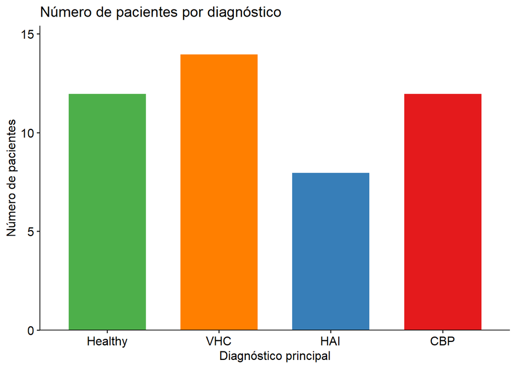

```r
ggplot(datos_clinicos_metabolomicos, aes(x = diagnostico_principal, fill = diagnostico_principal)) +
  geom_bar(color = "white", width = 0.7) +
  scale_fill_manual(values = paleta) +
  scale_y_continuous(expand = expansion(mult = c(0, 0.1))) +
  theme_pubr() +
  labs(title = "Número de pacientes por diagnóstico",
       x = "Diagnóstico principal", y = "Número de pacientes") +
  theme(legend.position = "none")
```

El gráfico representa el **volumen total de la muestra** distribuido en las 4 categorías de diagnóstico principal. El grupo con mayor cantidad de individuos es el de pacientes con **VHC** (14), seguido por un empate entre el grupo de control **Healthy** y los pacientes con **CBP** (12 cada uno), mientras que la condición de **HAI** registra la menor representación con 8 pacientes.

## B) Distribución del sexo por grupos de diagnóstico

Se analiza la distribución del sexo dentro de cada grupo diagnóstico, tanto en términos absolutos como relativos.

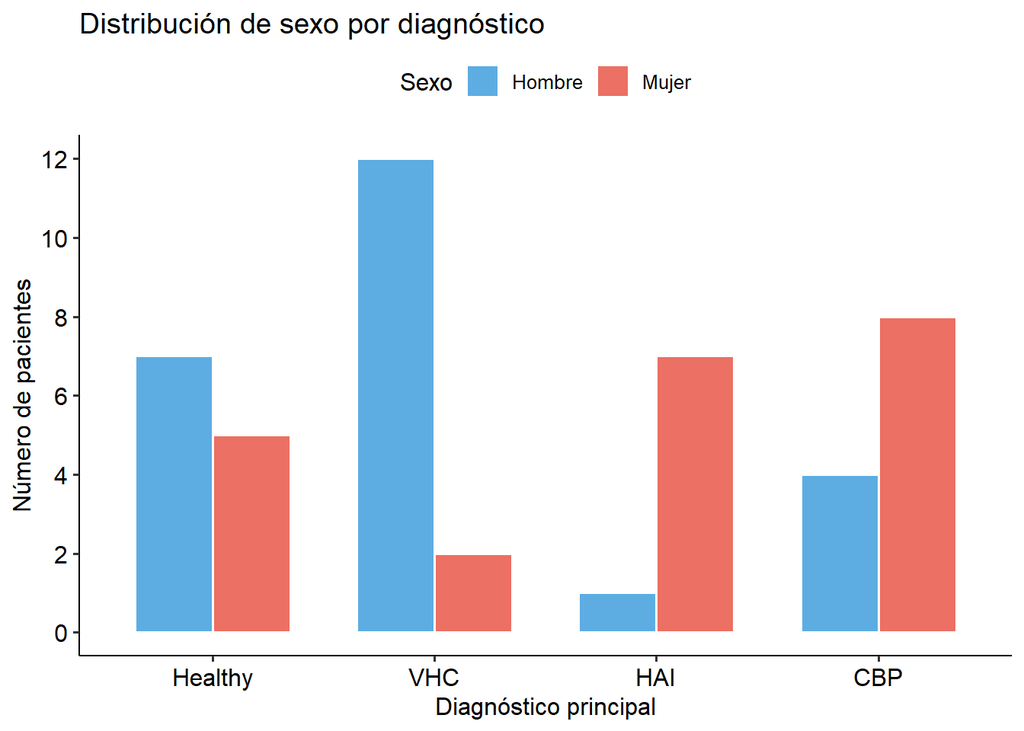

```r
library(ggplot2)
library(scales)

#Con nº de pacientes
ggplot(datos_clinicos_metabolomicos, aes(x = diagnostico_principal, fill = genero)) +
  geom_bar(position = "dodge", color = "white", width = 0.7) +
  scale_fill_manual(values = c("M" = "#5DADE2", "F" = "#EC7063"),
                    labels = c("M" = "Hombre", "F" = "Mujer")) +
  scale_y_continuous(breaks = scales::pretty_breaks(n = 5)) +
  theme_pubr() +
  labs(title = "Distribución de sexo por diagnóstico",
       x = "Diagnóstico principal", y = "Número de pacientes", fill = "Sexo")
```

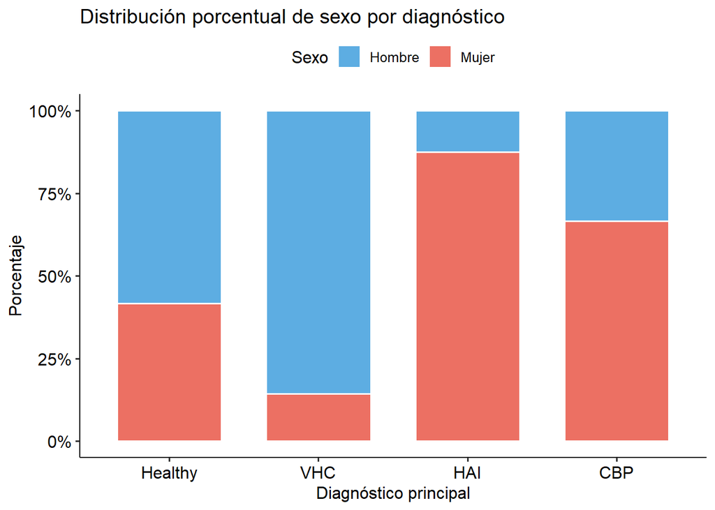

```r
#Con porcentajes
ggplot(datos_clinicos_metabolomicos,
       aes(x = diagnostico_principal, fill = genero)) +

  geom_bar(position = "fill", color = "white", width = 0.7) +

  scale_fill_manual(values = c("M" = "#5DADE2", "F" = "#EC7063"),
                    labels = c("M" = "Hombre", "F" = "Mujer")) +

  scale_y_continuous(labels = scales::percent_format()) +

  theme_pubr() +

  labs(title = "Distribución porcentual de sexo por diagnóstico",
       x = "Diagnóstico principal",
       y = "Porcentaje",
       fill = "Sexo")
```

## C) Distribución de la edad por grupos de diagnóstico (con p-valor global y comparaciones pareadas)

Se representa la distribución de la edad entre los distintos grupos diagnósticos.

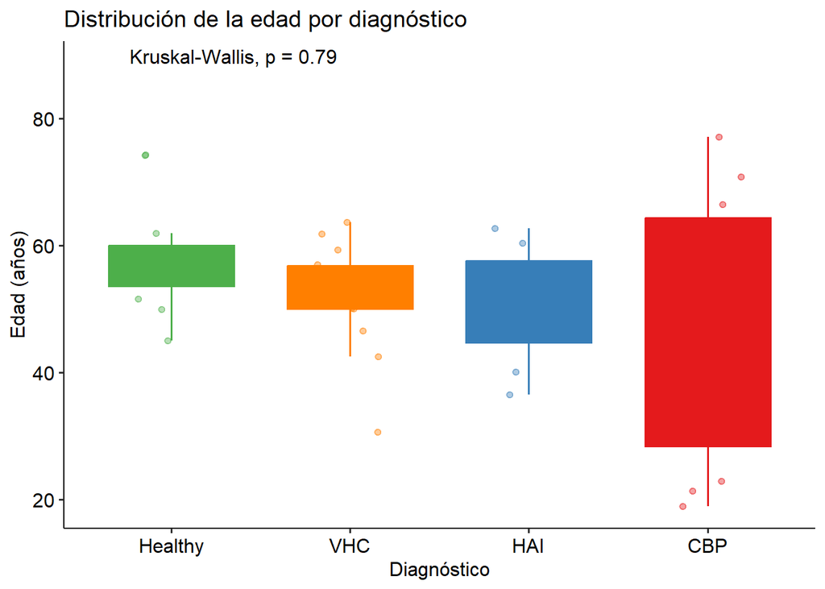

```r
# Extraer comparaciones significativas para edad desde tu tabla inferencial
comp_edad <- estadistica_inferencial_clinica %>%
  filter(Variable == "idade") %>%
  pull(posthoc_pvalue) %>%
  extraer_comparaciones()

p_edad <- ggboxplot(datos_clinicos_metabolomicos,
                    x = "diagnostico_principal", y = "idade",
                    fill = "diagnostico_principal",
                    color = "diagnostico_principal",
                    palette = paleta,
                    add = "jitter", add.params = list(alpha = 0.4, size = 1.5)) +
  stat_compare_means(method = "kruskal.test",
                     label.y = max(datos_clinicos_metabolomicos$idade, na.rm = TRUE) * 1.15) +
  { if (!is.null(comp_edad))
    stat_compare_means(comparisons = comp_edad,
                       method = "wilcox.test",
                       label = "p.signif",
                       hide.ns = TRUE) } +
  theme_pubr() +
  labs(title = "Distribución de la edad por diagnóstico",
       x = "Diagnóstico", y = "Edad (años)") +
  theme(legend.position = "none")

p_edad
```

El gráfico muestra que las medianas de edad son bastante similares entre los cuatro grupos diagnósticos (entre 50 y 60 años), siendo el grupo de **CBP** el que presenta la mayor dispersión y variabilidad de edades. Estadísticamente, el valor de **p = 0.79** obtenido mediante la prueba de **Kruskal-Wallis** (>0.05) demuestra que **no existen diferencias significativas** en la distribución de la edad entre los diferentes grupos, lo que confirma que las cohortes están correctamente homogeneizadas o balanceadas respecto a esta variable.

## D) TOP 10 metabolitos mas significativos en cada enfermedad (función reutilizable con ggpubr)

Se visualizan los 10 metabolitos más significativos entre grupos diagnósticos mediante representaciones tipo boxplot con comparaciones estadísticas.

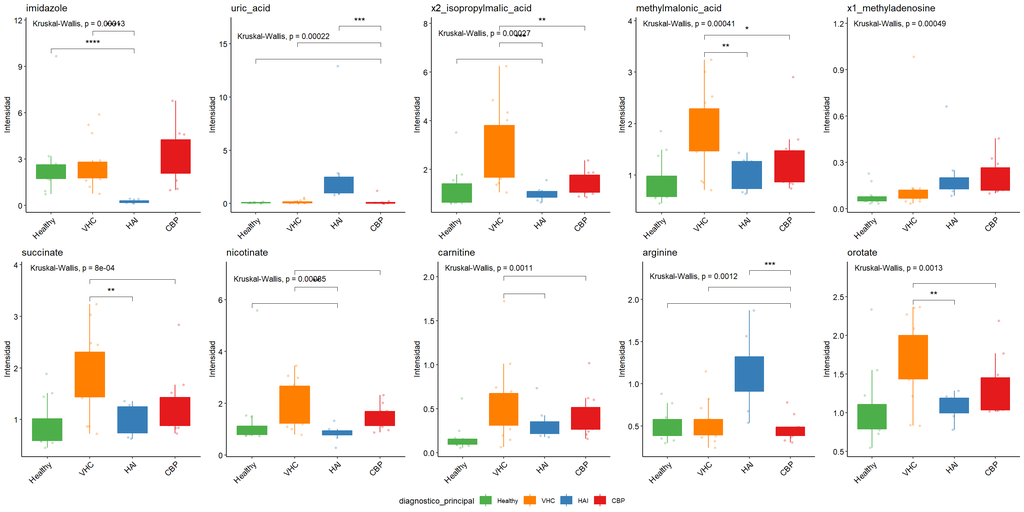

```r
top_metabolitos <- metabolitos_signif %>%
  slice_head(n = 10) %>%
  pull(Variable)

plots_metabolitos <- lapply(top_metabolitos, function(met) {

  comp <- estadistica_inferencial_metabolitos %>%
    filter(Variable == met) %>%
    pull(posthoc_pvalue) %>%
    extraer_comparaciones()

  p_glob <- estadistica_inferencial_metabolitos %>%
    filter(Variable == met) %>%
    pull(p.value)

  y_max <- max(datos_clinicos_metabolomicos[[met]], na.rm = TRUE)

  g <- ggboxplot(datos_clinicos_metabolomicos,
                 x = "diagnostico_principal",
                 y = met,
                 fill = "diagnostico_principal",
                 color = "diagnostico_principal",
                 palette = paleta,
                 add = "jitter",
                 add.params = list(alpha = 0.3, size = 1)) +
    stat_compare_means(method = "kruskal.test",
                       label.y = y_max * 1.2,
                       size = 3) +
    { if (!is.null(comp))
      stat_compare_means(comparisons = comp,
                         method = "wilcox.test",
                         label = "p.signif",
                         hide.ns = TRUE) } +
    theme_pubr(base_size = 9) +
    labs(title = met, x = NULL, y = "Intensidad") +
    theme(legend.position = "none",
          axis.text.x = element_text(angle = 45, hjust = 1))

  return(g)
})

# Montar en una sola figura (2 filas × 5 columnas)
ggarrange(plotlist = plots_metabolitos,
          ncol = 5, nrow = 2,
          common.legend = TRUE, legend = "bottom")
```

Los niveles de intensidad de los 10 metabolitos más significativos varían de forma significativa entre los grupos diagnósticos (todos con p < 0.05 en la prueba global Kruskal-Wallis). Se observan perfiles biomarcadores diferenciados para cada patología: por ejemplo, *HAI* destaca por niveles elevados de *uric_acid* y *arginine*, y por una reducción drástica de *imidazole*. Por su parte, *VHC* se caracteriza por un incremento marcado en metabolitos como *x2_isopropylmalic_acid*, *methylmalonic_acid*, *succinate* y *orotate*, mientras que *CBP* exhibe la mayor intensidad en *imidazole* y *x1_methyladenosine*. Las comparaciones post-hoc (indicadas con los asteriscos *) confirman qué grupos específicos sostienen estas diferencias biológicas frente al grupo control sano o entre las propias hepatopatías.

## E) TOP 10 variables clínicas numéricas mas significativas en cada enfermedad (función reutilizable con ggpubr)

Se representan las 10 variables clínicas numéricas más significativas entre grupos diagnósticos mediante boxplots con análisis estadístico asociado.

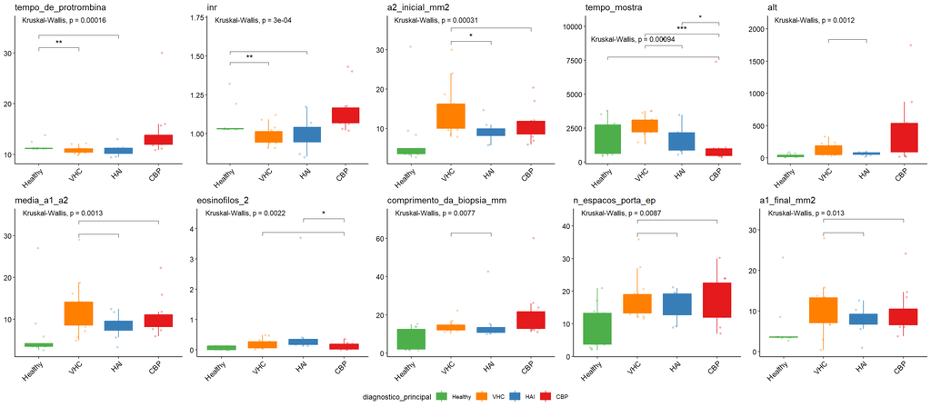

```r
top_clinicas_num <- clinica_signif %>%
  filter(Variable %in% vars_num) %>%
  slice_head(n = 10) %>%
  pull(Variable)

plots_clinicas_num <- lapply(top_clinicas_num, function(var) {

  comp <- estadistica_inferencial_clinica %>%
    filter(Variable == var) %>%
    pull(posthoc_pvalue) %>%
    extraer_comparaciones()

  y_max <- max(datos_clinicos_metabolomicos[[var]], na.rm = TRUE)

  g <- ggboxplot(datos_clinicos_metabolomicos,
                 x = "diagnostico_principal",
                 y = var,
                 fill = "diagnostico_principal",
                 color = "diagnostico_principal",
                 palette = paleta,
                 add = "jitter",
                 add.params = list(alpha = 0.3, size = 1)) +
    stat_compare_means(method = "kruskal.test",
                       label.y = y_max * 1.2,
                       size = 3) +
    { if (!is.null(comp))
      stat_compare_means(comparisons = comp,
                         method = "wilcox.test",
                         label = "p.signif",
                         hide.ns = TRUE) } +
    theme_pubr(base_size = 9) +
    labs(title = var, x = NULL, y = NULL) +
    theme(legend.position = "none",
          axis.text.x = element_text(angle = 45, hjust = 1))

  return(g)
})

ggarrange(plotlist = plots_clinicas_num,
          ncol = 5, nrow = 2,
          common.legend = TRUE, legend = "bottom")
```

## F) TOP 10 variables clinicas categoricas mas significativas en cada enfermedad (función reutilizable con ggpubr)

Se visualizan las variables clínicas categóricas más relevantes mediante gráficos de barras apiladas, mostrando la distribución por diagnóstico.

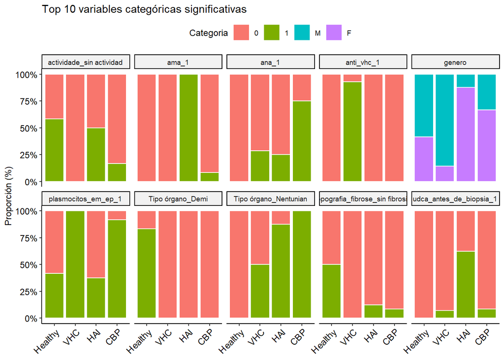

```r
# Para categóricas ggpubr no añade comparaciones pareadas igual, así que mantengo barras apiladas con el p-valor global encima

top_clinicas_cat <- clinica_signif %>%
  filter(Variable %in% vars_cat) %>%
  slice_head(n = 10) %>%
  pull(Variable)

datos_clinicos_metabolomicos %>%
  select(diagnostico_principal, all_of(top_clinicas_cat)) %>%
  pivot_longer(-diagnostico_principal, names_to = "Variable", values_to = "Categoria") %>%
  ggplot(aes(x = diagnostico_principal, fill = Categoria)) +
  geom_bar(position = "fill", color = "white") +
  facet_wrap(~ Variable, ncol = 5) +
  scale_y_continuous(labels = scales::percent) +
  theme_pubr(base_size = 9) +
  labs(title = "Top 10 variables categóricas significativas",
       x = NULL, y = "Proporción (%)") +
  theme(axis.text.x = element_text(angle = 45, hjust = 1))
```